# Read in Initial Data

2024-08-17

*WARNING:* You MUST run this script from top to bottom. Running only part of it will result in errors. Data frames are named the same thing at the begining of the script as the end. This improves performance in large data sets, but means that great care should be taken when the script is not run from top to bottom.

*FIRST* Be sure to set up your farm name and state name on lines 45 and 46 if you are not going to customize the functions to set these.

*NEXT* Pull events from dairy comp using this code:

Option 1 Pull 5 years in one file: EVENTS\2S2000C #1 #2 #4 #5 #6 #11 #12 #13 #15 #28 #29 #30 #31 #32 #38 #40 #43

Option 2 pull smaller time frames using “days back” starting with “S”“days back” and ending with “L”“days back”: EVENTS\2S99L0C #1 #2 #4 #5 #6 #11 #12 #13 #15 #28 #29 #30 #31 #32 #38 #40 #43

This code pulls the following items along with the columns always generated with an events2 command in DC305:

“ID” “PEN” “REG” “EID” “CBRD” “BDAT” “EDAT” “LACT” “RC” “HDAT” “FDAT” “CDAT” “DDAT” “PODAT” “ABDAT” “VDAT” “ARDAT”

“Event” “DIM” “Date” “Remark” “Protocols” “R” “T” “B” “Technician”

*THEN* Place your files in this folder “Data/EventFiles”

The code in chunk 3 will read in all files in this folder so do not leave old files here that you do not want to process.

*FINALLY* Turn on/off (comment/un-comment) lines 127 and 129 to use custom functions for event types and source farm/state

## Initial Processing Report

#### Start date: 2019-01-01

#### End date: 2024-12-14

### Animal Counts

| year | Heifer | LACT 1 |
| --- | --- | --- |
| 2019 | 69599 | 85 |
| 2020 | 97977 | 32 |
| 2021 | 122321 | 4 |
| 2022 | 137925 | 4 |
| 2023 | 153476 | NA |
| 2024 | 135850 | 1 |

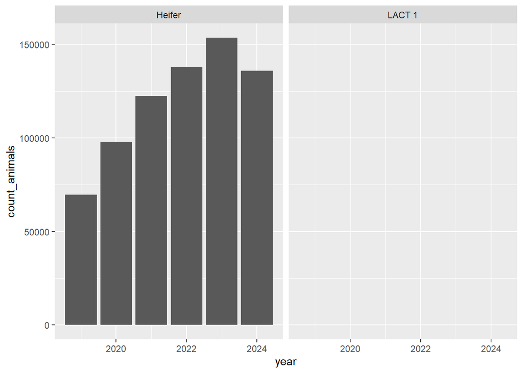

### QC Event Types

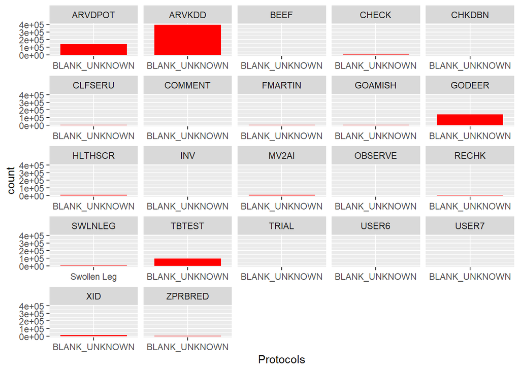

### QC Source Farms

```
## [1] "All Source Farms Mapped"
```

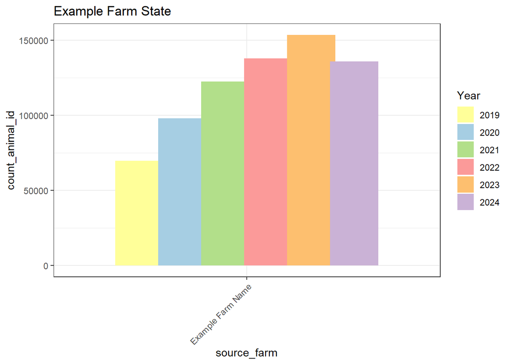

### Main Data

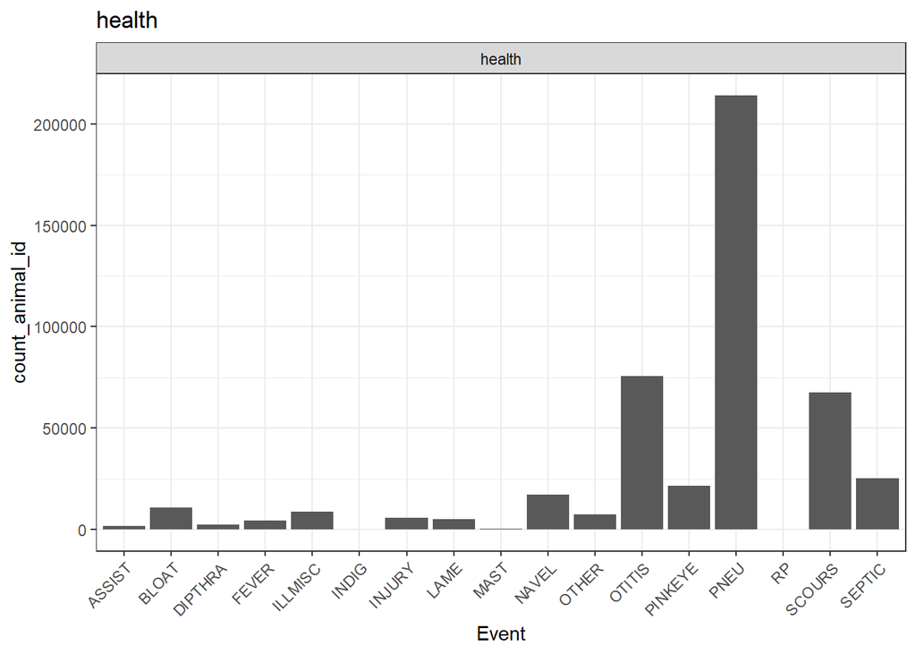

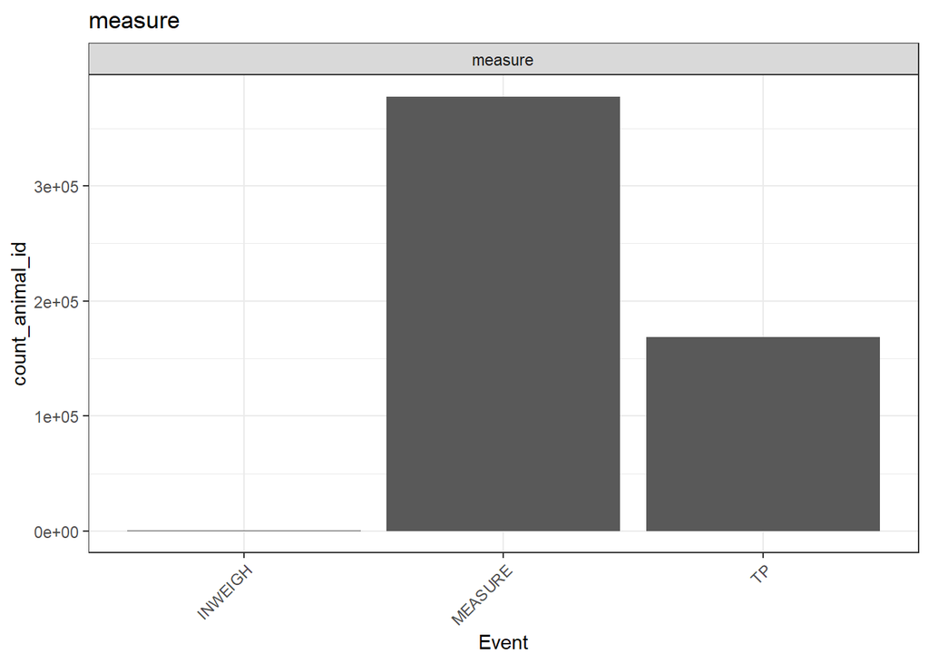

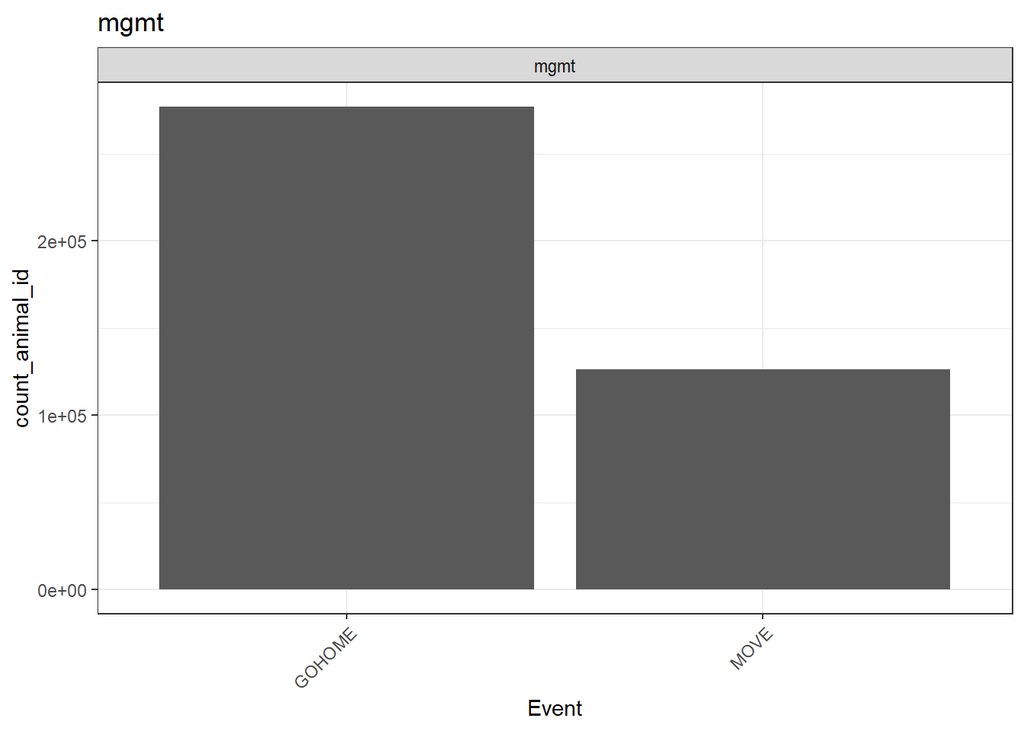

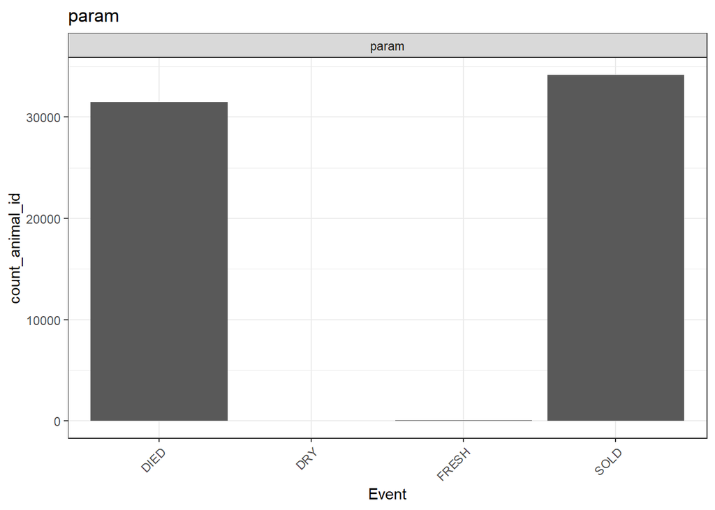

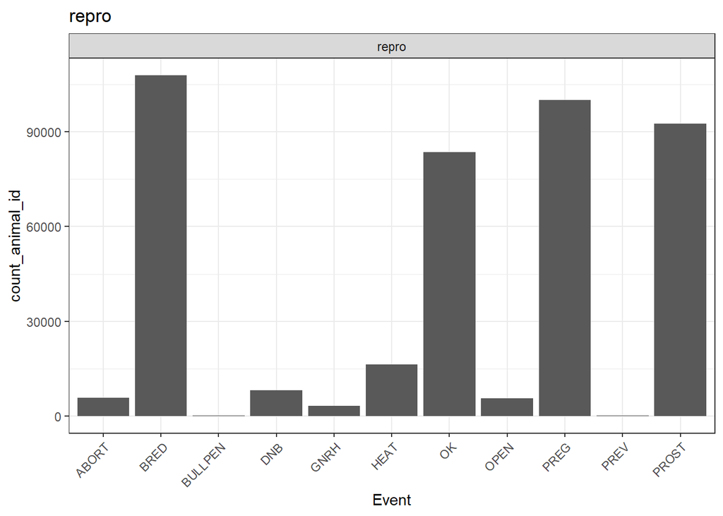

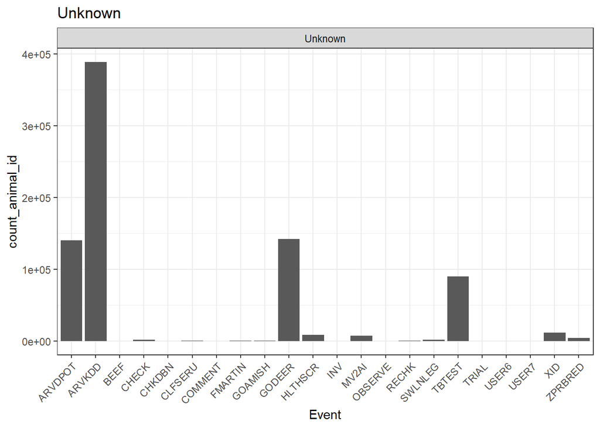

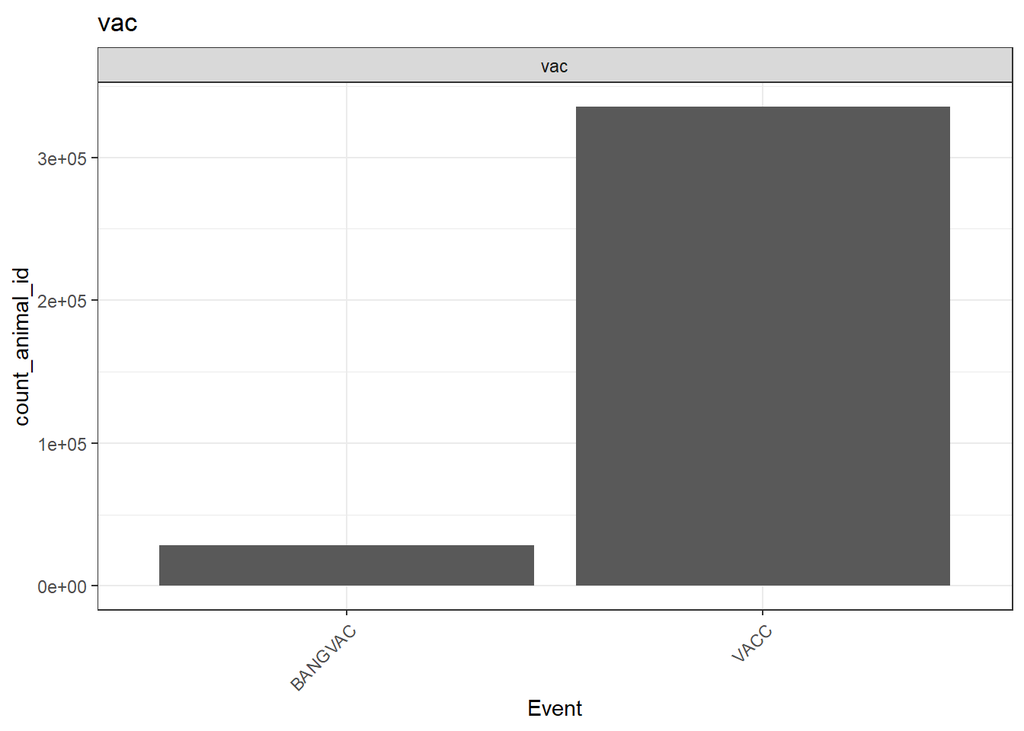